# DATA Assessment 2023-24

## Department of Computer Science, University of York

### DATA: Introduction to Data Science

## Task 1: Domain Analysis (5 marks)

Given the business domain and the data overview presented (in the assessment paper), provide a brief description of

- the business problem and its significance to the relevant sector;
- the link between the business problem and the field of data science;
- the main areas of investigation; and
- potential ideas and solutions.

**Word Limit:** 300 words

**Write your answer here (text cell(s) to be used, as appropriate)**

The UK finance sector is a competitive market with many banks offering a range of incentives. In order to have the greatest advantage for success it is pivotal to use data in order to achieve this. By using data driven research it allows the bank to gain further insight into its customers spending habits enabling them to provide a more detailed and accurate tailoring when facilitating the provisions of loans, issuing credit cards to different customer needs and overseeing a wide range of financial transactions. This therefore allows them to inform more precise data-driven decision making.

The field of data science allows us to explore and analyse key pieces of data and manipulate them into findings that enables stakeholders to gain an insight into consumer needs by extracting patterns from large datasets such as transactions and demographic statistics. This allows us to create predictive models that forecasts future activity based on historical activity creating a great resource for decision making

One of the main areas of investigation is transactions, this is vital when thinking about the finance sector as it is the most significant factor when trying to predict future patterns and behaviours whilst also analysing potential anomalies. A solution to this is to develop a predictive model based on historical spending allowing the bank to identify high value customers.

Assessing credit card usage and apply credit scores to customers is another area of investigation as it is vital to be able to keep track of client spending in order to determine if certain customers need larger or smaller limits. Not only will this increase customer satisfaction but also increase risk management for the bank. Using past credit usage history we can use that to train a model to predict future usage and assign scores to customers.

## Task 2: Database Design (25 marks)

Having understood the business domain, present a conceptual design in the form of an entity-relationship (ER) model that would be helpful in creating a database for the bank.

The bank data currently exists in the form of a csv file called *BankRecords.csv*, provided on VLE (path given in page 5, assessment paper). This file has all the existing records. The table available in the csv file is unnormalised. The information about its different columns is given in Tables 1 and 2 (in the assessment paper).

Following the standard principles of database normalisation, normalise the given table (*BankRecords.csv*) to a database schema that has minimum redundancies. Then, using the designed schema, create an SQLite database.

Your answer should include the SQL statements needed to accomplish this step. Your submission should also include the created SQLite database file.

Your answer should clearly cover the following:

- Any assumptions you are making about the given scenario;
- The designated keys, existing relationships, and identified functional dependencies;
- The steps followed and justifications for the decisions made.

**World Limit**: 500 words. This limit applies only to the explanations. There is no limit on any associated code/SQL statements or figures.

**Write your answer here (text cell(s) to be used, as appropriate)**

```python
import pandas as pd

df = pd.read_csv('BankRecords.csv', low_memory=False)

client_df = df[['client_id', 'birth_number', 'a1']].drop_duplicates()
client_df = client_df.dropna(subset=['client_id'])

account_df = df[['account_id', 'frequency', 'creation_date', 'client_id']].drop_duplicates()
account_df.drop_duplicates(subset='account_id', keep='first', inplace=True)
account_df = account_df.dropna(subset=['account_id'])

transaction_df = df[['trans_id', 'trans_detail', 'trans_amount', 'trans_date', 'trans_type', 'balance', 'operation', 'partner_account', 'partner_bank', 'account_id']].drop_duplicates()
transaction_df = transaction_df.dropna(subset=['trans_id'])

loans_df = df[['loan_id', 'loan_date', 'account_id' , 'loan_amount', 'loan_duration', 'loan_payments', 'loan_status']].drop_duplicates()
loans_df = loans_df.dropna(subset=['loan_id'])

order_df = df[['order_id', 'bank_to', 'order_amount', 'account_id', 'account_to', 'payment_type']].drop_duplicates()
order_df = order_df.dropna(subset=['order_id'])

card_df = df[['card_id', 'disp_id', 'card_issued', 'card_type']].drop_duplicates()
card_df = card_df.dropna(subset=['card_id'])

disposition_df = df[['disp_id', 'disp_type', 'account_id', 'client_id']].drop_duplicates()
disposition_df = disposition_df.dropna(subset=['disp_id'])

a_df = df[['a1', 'a3', 'a4', 'a5', 'a6', 'a7', 'a8', 'a9', 'a10', 'a11', 'a12', 'a13', 'a14', 'a15', 'a16']].drop_duplicates()
a_df = a_df.dropna(subset=['a1'])
```

```python
import sqlite3
conn = sqlite3.connect('BankRecords.db')
```

```python
import sqlite3

conn = sqlite3.connect('BankRecords.db')
cursor = conn.cursor()
cursor.execute('PRAGMA foreign_keys = ON')

#Client
cursor.execute('''CREATE TABLE client_df (
                    client_id INTEGER PRIMARY KEY,
                    birth_number INTEGER,
                    a1 INTEGER,
                    FOREIGN KEY (a1) REFERENCES a_df(a1))''')

conn.commit()
```

```python
#Account
cursor.execute('''CREATE TABLE account_df (
                    account_id INTEGER PRIMARY KEY,
                    frequency INTEGER,
                    creation_date INTEGER,
                    client_id INTEGER,
                    FOREIGN KEY (client_id) REFERENCES client_df(client_id))''')

conn.commit()
```

```python
#Transaction
cursor.execute('''CREATE TABLE transaction_df (
        trans_id INTEGER PRIMARY KEY,
        trans_detail TEXT,
        account_id INTEGER,
        trans_amount REAL,
        trans_date INTEGER,
        trans_type TEXT,
        balance REAL,
        operation TEXT,
        partner_account INTEGER,
        partner_bank TEXT,
        FOREIGN KEY (account_id) REFERENCES account_df(account_id))''')

conn.commit()
```

```python
#Loans

cursor.execute(''' CREATE TABLE loans_df (
        loan_id REAL PRIMARY KEY,
        loan_date INTEGER,
        account_id INTEGER,
        loan_amount REAL,
        loan_duration INTEGER,
        loan_payments REAL,
        loan_status TEXT,
        FOREIGN KEY (account_id) REFERENCES account_df(account_id))''')

conn.commit()
```

```python
#Order

cursor.execute('''CREATE TABLE order_df (
                    order_id REAL PRIMARY KEY,
                    bank_to TEXT,
                    order_amount REAL,
                    account_id INTEGER,
                    account_to INTEGER,
                    payment_type TEXT,
                    FOREIGN KEY (account_id) REFERENCES account_df(account_id))''')

conn.commit()
```

```python
#Disposition

cursor.execute('''CREATE TABLE disposition_df (
                    disp_id INTEGER PRIMARY KEY,
                    disp_type TEXT,
                    account_id INTEGER,
                    client_id INTEGER,
                    FOREIGN KEY (account_id) REFERENCES account_df(account_id)
                    FOREIGN KEY (client_id) REFERENCES client_df(client_id))''')

conn.commit()
```

```python
#Card

cursor.execute('''CREATE TABLE card_df (
                    card_id REAL PRIMARY KEY,
                    disp_id INTEGER,
                    card_issued INTEGER,
                    card_type TEXT,
                    FOREIGN KEY (disp_id) REFERENCES disposition_df(disp_id))''')

conn.commit()
```

```python
#A Table
cursor.execute('''CREATE TABLE a_df (
                    a1 INTEGER PRIMARY KEY,
                    a3 TEXT,
                    a4 INTEGER,
                    a5 INTEGER,
                    a6 INTEGER,
                    a7 INTEGER,
                    a8 INTEGER,
                    a9 INTEGER,
                    a10 REAL,
                    a11 INTEGER,
                    a12 REAL,
                    a13 REAL,
                    a14 INTEGER,
                    a15 INTEGER,
                    a16 INTEGER)''')

conn.commit()
```

```python
#A Table info

for index, row in a_df.iterrows():
    cursor.execute(
        'INSERT INTO a_df (a1, a3 ,a4 ,a5 ,a6 ,a7 ,a8 ,a9 ,a10 ,a11 ,a12 ,a13 ,a14 ,a15 ,a16) VALUES (?, ?, ?, ?, ?, ?, ?, ?, ?, ? ,? ,? ,? ,? ,?)',
    (row['a1'], row['a3'], row['a4'], row['a5'] ,row['a6'], row['a7'], row['a8'], row['a9'], row['a10'], row['a11'], row['a12'], row['a13'], row['a14'], row['a15'], row['a16']))

conn.commit()
```

```python
#Client table info

for index, row in client_df.iterrows():
    cursor.execute(
        'INSERT INTO client_df (client_id, birth_number, a1) VALUES (?, ?, ?)',
        (int(row['client_id']), int(row['birth_number']), int(row['a1'])))

conn.commit()
```

```python
#Account table info

for index, row in account_df.iterrows():
    cursor.execute(
        'INSERT INTO account_df (account_id, frequency, creation_date, client_id) VALUES (?, ?, ?, ?)',
        (row['account_id'], row['frequency'], row['creation_date'], row['client_id']))

conn.commit()
```

```python
#Transaction table info

for index, row in transaction_df.iterrows():
    cursor.execute(
        'INSERT INTO transaction_df (trans_id, trans_detail, account_id, trans_amount, trans_date, trans_type, balance, operation, partner_account, partner_bank) VALUES (?, ?, ?, ?, ?, ?, ?, ?, ?, ?)',
        (row['trans_id'], row['trans_detail'], row['account_id'], row['trans_amount'], row['trans_date'], row['trans_type'], row['balance'], row['operation'], row['partner_account'], row['partner_bank']))

conn.commit()
```

```python
#Loans table info

for index, row in loans_df.iterrows():
    cursor.execute(
        'INSERT INTO loans_df (loan_id, loan_date, account_id, loan_amount, loan_duration, loan_payments, loan_status) VALUES (?, ?, ?, ?, ?, ?, ?)',
        (row['loan_id'], row['loan_date'], row['account_id'], row['loan_amount'], row['loan_duration'], row['loan_payments'], row['loan_status']))

conn.commit()
```

```python
#Order table info

for index, row in order_df.iterrows():
    cursor.execute(
        'INSERT INTO order_df (order_id, account_id , bank_to, account_to, order_amount, payment_type) VALUES (?, ?, ?, ?, ?, ?)',
        (row['order_id'], row['account_id'], row['bank_to'], row['account_to'], row['order_amount'], row['payment_type']))

conn.commit()
```

```python
#Disposition table info

for index, row in disposition_df.iterrows():
    cursor.execute(
        'INSERT INTO disposition_df (disp_id, disp_type, account_id, client_id) VALUES (?, ?, ?, ?)',
        (row['disp_id'], row['disp_type'], row['account_id'], row['client_id']))

conn.commit()
```

```python
#Card table info

for index, row in card_df.iterrows():
    cursor.execute(
        'INSERT INTO card_df (card_id, disp_id, card_type, card_issued) VALUES (?, ?, ?, ?)',
        (row['card_id'], row['disp_id'], row['card_type'], row['card_issued']))

conn.commit()
```

Upon creating my Entity Relationship model, I initially started by looking at the two tables provided and organising them into categories which would later become the tables in the database, Loans, Transactions, Card, Order, Disposition, Area (a), Account and Client. Each table then gained their individual attributes. I then further analysed each table and found which attribute would become the primary key by seeing how the attributes could be identified by looking at one individual column. These primary keys, typically became the attribute that held the ID. Once all the tables had become individually complete I was able to see what relationships the tables had in order to determine foreign keys. Whilst doing this, I removed the column 'a2' from the Area (a) table in order to remove any dependencies as it is viable to use 'a1' instead, further normalising the database. This constituted of making a further schematic diagram of a Relational Database which highlights all relationships and their foreign keys in order to make sure no further mistakes or dependancies were missed. An example of the relationships is the client table which has a primary key of 'client_id'. However within the Account table it is a foreign key. This was designed so every account can be linked back to the individual client so all activities can be monitored and traced back to the client.

After this, I created my own database by importing sqlite3 and connecting it to a .db file named 'BankRecords'. Using sql commands I created each individual table including their attributes, primary keys and foreign keys. Whilst doing this, I defined each attributes data type such as Integer, Real or Text based on my analysis of the original csv file. Once all these had been created I now had the skeleton of the database however needed to import the actual data within each table.

In order to do this, I used for loops joined to sql statements that connected to tables I had made from the csv file. The for loops iterated through each row and column inserting it into the database for each table and committing the connection in order to maintain the data and integrity of it. Once the data was input into the BankRecords.db file that I had created, I was able to download it and analyse my new Database to begin designing modelling solutions.

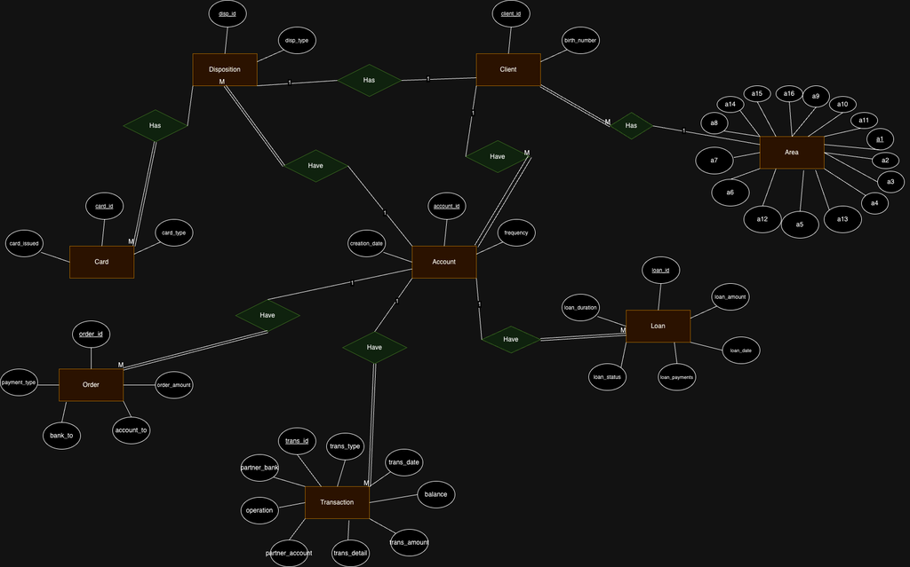

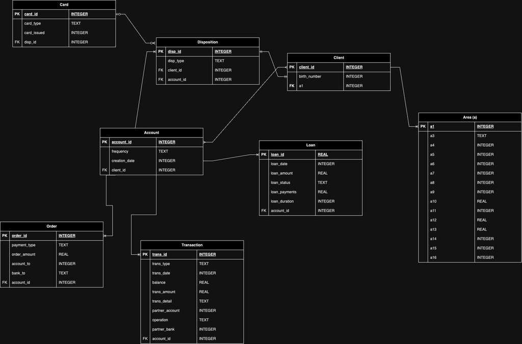

## Task 3: Research Design (25 Marks)

Using the database designed in Task 2, design and implement **five** potential modelling solutions to achieve the aim of the Data Intelligence team. You need to provide clear justifications about the techniques selected in the context of the 'problem in hand'. Your design must consist of a combination of inferential statistics, supervised learning algorithms, and unsupervised learning algorithms, and include **at least one** of those techniques. Finally, your modelling solutions should be of sufficient complexity, combining information from multiple tables from the database built in Task 2, as appropriate. Your answer should clearly show the queries made to the database. If amendments are made to the database, the commands should be clearly included in your answer.

Your answer should clearly cover the following:

- Any assumptions you are making about the given scenario;
- Any data processing and data integrity steps you would undertake to make the data fit for purpose;
- Which technique(s) you would apply for each solution and why;
- An evaluation of the techniques applied in terms of the accuracy of their results (or any other suitable evaluation measure);
- Algorithmic parameters should be adequately stated and discussed;
- A discussion of ethical considerations arising from the solutions selected.

**World Limit**: 500 words. This limit applies only to the explanations. There is no limit on any associated code or figures.

**Write your answer here (text cell(s) to be used, as appropriate)**

```python
from datetime import datetime
import pandas as pd
import sqlite3

conn = sqlite3.connect('BankRecords.db')

sql_query = """
SELECT birth_number FROM client_df
"""

def calculate_age(birth_number):
    year = birth_number // 10000
    month = (birth_number % 10000) // 100

    if month > 50:
        month -= 50

    current_year = 1999
    full_birth_year = 1900 + year

    age = current_year - full_birth_year

    return age

def categorise_age_group(age):
    age_threshold = data['age'].mean()
    return '>=50' if age > age_threshold else '<50'

data = pd.read_sql_query(sql_query, conn)

data['age'] = data['birth_number'].apply(calculate_age)
data['age_group'] = data['age'].apply(categorise_age_group)
```

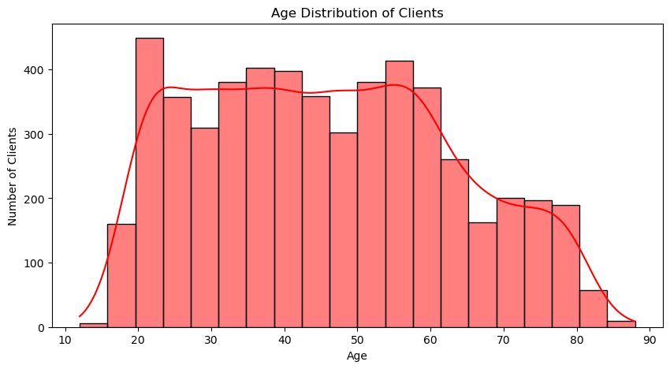

```python
import matplotlib.pyplot as plt
import seaborn as sns

plt.figure(figsize=(10, 5))
sns.histplot(data['age'], bins=20, kde=True, color='red', ec='black', fill=True)
plt.title('Age Distribution of Clients')
plt.xlabel('Age')
plt.ylabel('Number of Clients')
plt.show()
```

```python
from datetime import datetime

sql_query = """
SELECT trans_date FROM transaction_df
"""

def calculate_month_name(trans_date):
    Myear = trans_date // 10000
    Mmonth = (trans_date % 10000) // 100

    if Mmonth > 50:
        Mmonth -= 50

    Mfull_year = 1900 + Myear

    date_object = datetime(year=Mfull_year, month=Mmonth, day=1)

    month_name = date_object.strftime("%B")

    return month_name

def calculate_month_number(trans_date):
    # Extract year and month from trans_date
    Myear = trans_date // 10000
    Mmonth = (trans_date % 10000) // 100

    if Mmonth > 50:
        Mmonth -= 50

    return Mmonth


def calculate_loan_month(loan_date):
    Myear = loan_date // 10000
    Mmonth = (loan_date % 10000) // 100

    if Mmonth > 50:
        Mmonth -= 50

    Mfull_year = 1900 + Myear

    date_object = datetime(year=Mfull_year, month=Mmonth, day=1)

    month_name = date_object.strftime("%B")

    return month_name

def calculate_year(trans_date):
    year = trans_date // 10000
    month = (trans_date % 10000) // 100

    if month > 50:
        month -= 50

    current_year = 1999
    full_birth_year = 1900 + year

    age = full_birth_year

    return age
```

Assuming the current year is 1999 based on the latest transaction

## Predicting Mean Loan Amounts and Transaction Amounts by Months

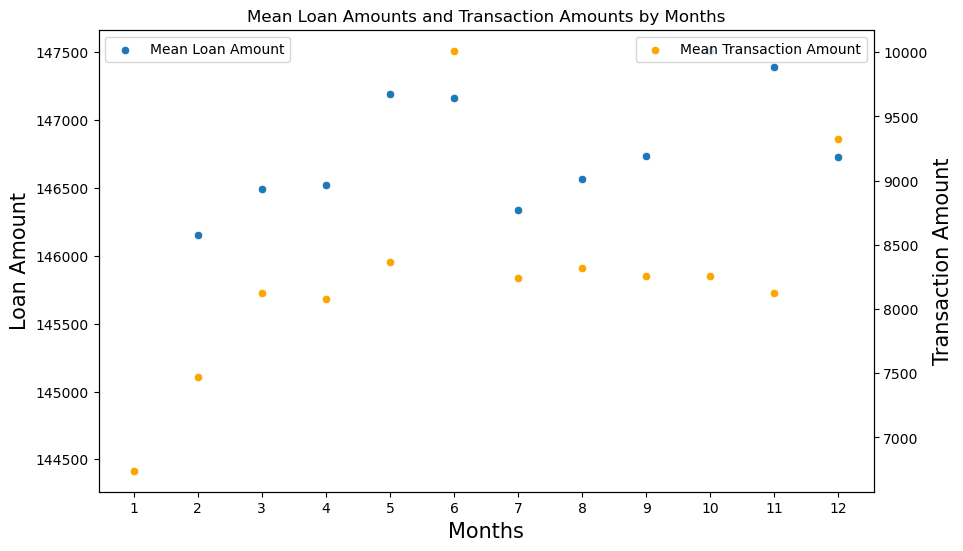

```python
import pandas as pd
import numpy as np
import sqlite3
import matplotlib.pyplot as plt

conn = sqlite3.connect('BankRecords.db')

sql_query = """
SELECT t.trans_date, t.trans_amount, l.loan_amount
FROM transaction_df t
JOIN loans_df l ON l.account_id = t.account_id
"""


data = pd.read_sql_query(sql_query, conn)


data['trans_month'] = data['trans_date'].apply(calculate_month_name)


month_to_number = {
    'January': 1, 'February': 2, 'March': 3, 'April': 4,
    'May': 5, 'June': 6, 'July': 7, 'August': 8,
    'September': 9, 'October': 10, 'November': 11, 'December': 12
}


data['trans_month'] = data['trans_month'].map(month_to_number)


mean_loans_by_month = data.groupby('trans_month')['loan_amount'].mean().reset_index()
mean_transAmount_by_month = data.groupby('trans_month')['trans_amount'].mean().reset_index()


plt.figure(figsize=(10,6), dpi=100)
ax = sns.scatterplot(x="trans_month", y="loan_amount", data=mean_loans_by_month, marker='o', label='Mean Loan Amount')
ax.set_xlabel('Months', fontsize=15)
ax.set_ylabel('Loan Amount', fontsize=15)

ax2 = ax.twinx()
sns.scatterplot(x="trans_month", y="trans_amount", data=mean_transAmount_by_month, marker='o', color='orange', label='Mean Transaction Amount', ax=ax2)
ax2.set_ylabel('Transaction Amount', fontsize=15)

plt.title('Mean Loan Amounts and Transaction Amounts by Months')
plt.xticks(np.arange(1, 13))
plt.legend()
plt.show()
```

```
Intercept coefficient alpha for loan amount = 145646.544
Regression coefficient beta for loan amount = 147.026
Intercept coefficient alpha for trans amount = 7497.622
Regression coefficient beta for trans amount = 119.614
```

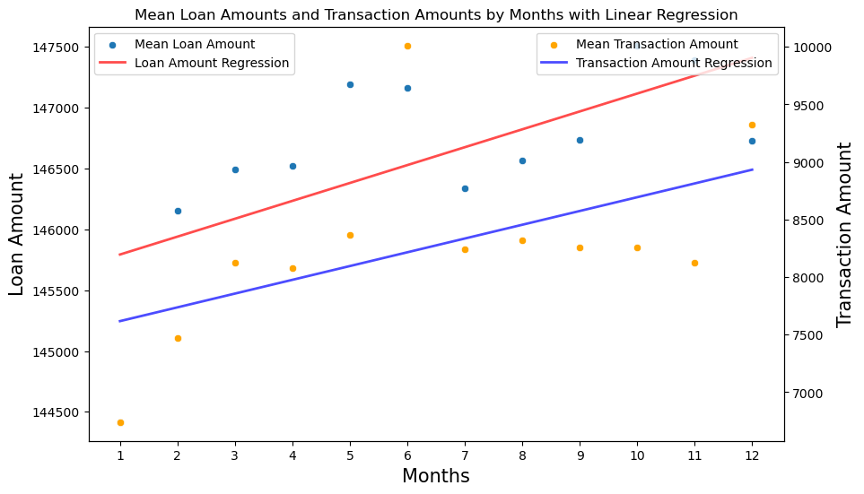

```python
import numpy as np
import matplotlib.pyplot as plt
import seaborn as sns
from scipy import stats
import math as m
import pandas as pd
import sqlite3
from sklearn import linear_model


conn = sqlite3.connect('BankRecords.db')


sql_query = """
SELECT t.trans_date, t.trans_amount, l.loan_amount
FROM transaction_df t
JOIN loans_df l ON l.account_id = t.account_id
"""

data = pd.read_sql_query(sql_query, conn)

data['trans_month'] = data['trans_date'].apply(calculate_month_name)

month_to_number = {
    'January': 1, 'February': 2, 'March': 3, 'April': 4,
    'May': 5, 'June': 6, 'July': 7, 'August': 8,
    'September': 9, 'October': 10, 'November': 11, 'December': 12
}


data['trans_month'] = data['trans_month'].map(month_to_number)

mean_loans_by_month = data.groupby('trans_month')['loan_amount'].mean().reset_index()

lrModel = linear_model.LinearRegression()

trainX = np.array(mean_loans_by_month['trans_month']).reshape(-1,1)
trainY = mean_loans_by_month['loan_amount']
lrModel.fit(X=trainX, y=trainY)

predictMonths = np.arange(1, 13).reshape(-1, 1)
predictBalance = lrModel.predict(predictMonths)

print("Intercept coefficient alpha for loan amount = %.3f" % (lrModel.intercept_))
print("Regression coefficient beta for loan amount = %.3f" % (lrModel.coef_[0]))

mean_transAmount_by_month = data.groupby('trans_month')['trans_amount'].mean().reset_index()


lrModel_transAmount = linear_model.LinearRegression()
trainX_transAmount = np.array(mean_transAmount_by_month['trans_month']).reshape(-1,1)
trainY_transAmount = mean_transAmount_by_month['trans_amount']
lrModel_transAmount.fit(X=trainX_transAmount, y=trainY_transAmount)


predictTransAmount = lrModel_transAmount.predict(predictMonths)

print("Intercept coefficient alpha for trans amount = %.3f" % (lrModel_transAmount.intercept_))
print("Regression coefficient beta for trans amount = %.3f" % (lrModel_transAmount.coef_[0]))


plt.figure(figsize=(10,6), dpi=100)
ax = sns.scatterplot(x="trans_month", y="loan_amount", data=mean_loans_by_month, marker='o', label='Mean Loan Amount')
ax.set_xlabel('Months', fontsize=15)
ax.set_ylabel('Loan Amount', fontsize=15)


ax2 = ax.twinx()
sns.scatterplot(x="trans_month", y="trans_amount", data=mean_transAmount_by_month, marker='o', color='orange', label='Mean Transaction Amount', ax=ax2)
ax2.set_ylabel('Transaction Amount', fontsize=15)


sns.lineplot(x=np.arange(1, 13), y=predictBalance, color="red", label="Loan Amount Regression", alpha=0.7, lw=2, ax=ax)
sns.lineplot(x=np.arange(1, 13), y=predictTransAmount, color="blue", label="Transaction Amount Regression", alpha=0.7, lw=2, ax=ax2)

plt.title('Mean Loan Amounts and Transaction Amounts by Months with Linear Regression')
plt.xticks(np.arange(1, 13))
plt.legend()
plt.show()
```

## Upgrade/Downgrade/No Change card types model

```python
import pandas as pd
import numpy as np
import sqlite3
import matplotlib.pyplot as plt
import seaborn as sns

conn = sqlite3.connect('BankRecords.db')

sql_query = """
SELECT
    t.trans_amount,
    t.account_id,
    ct.card_type
FROM transaction_df t
JOIN account_df a ON a.account_id = t.account_id
JOIN client_df c ON c.client_id = a.client_id
JOIN disposition_df d ON c.client_id = d.client_id
JOIN card_df ct ON d.disp_id = ct.disp_id
"""
data = pd.read_sql_query(sql_query, conn)

summed_trans_amount_by_account = data.groupby('account_id')['trans_amount'].sum().reset_index()

data_merged = pd.merge(data, summed_trans_amount_by_account, on='account_id', how='left')

data_merged.rename(columns={'trans_amount_y': 'total_trans_amount', 'trans_amount_x': 'trans_amount'}, inplace=True)

data_merged.drop('trans_amount', axis=1, inplace=True)

data_merged = data_merged.drop_duplicates(subset=['account_id', 'card_type'])

def determine_card_action(row):
    upgrade_threshold = 2000000
    if row['card_type'] == 'classic' and row['total_trans_amount'] > upgrade_threshold:
        return 'Upgrade to Gold'
    elif row['card_type'] == 'gold' and row['total_trans_amount'] < upgrade_threshold:
        return 'Downgrade to Classic'
    else:
        return 'No Change'

data_merged['card_action'] = data_merged.apply(determine_card_action, axis=1)

data_merged
```

|  | account_id | card_type | total_trans_amount | card_action |
| --- | --- | --- | --- | --- |
| 0 | 7 | gold | 1192039.9 | Downgrade to Classic |
| 105 | 14 | classic | 785858.0 | No Change |
| 204 | 33 | gold | 3231984.8 | No Change |
| 484 | 34 | classic | 4342630.5 | Upgrade to Gold |
| 830 | 43 | junior | 2841686.7 | No Change |
| ... | ... | ... | ... | ... |
| 183465 | 11079 | classic | 4041890.8 | Upgrade to Gold |
| 183673 | 11138 | classic | 5371586.0 | Upgrade to Gold |
| 183957 | 11141 | classic | 1696208.3 | No Change |
| 184087 | 11186 | junior | 4222458.4 | No Change |
| 184377 | 11359 | classic | 2948081.4 | Upgrade to Gold |

892 rows × 4 columns

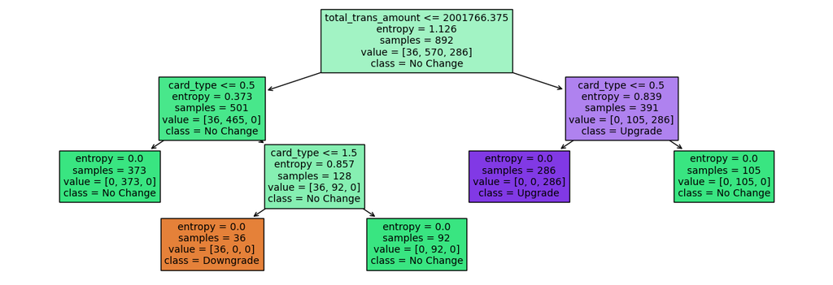

```python
from sklearn.model_selection import train_test_split
from sklearn.tree import DecisionTreeClassifier, plot_tree
from sklearn.metrics import classification_report
from sklearn.preprocessing import LabelEncoder
from sklearn import tree

Le = LabelEncoder()
data_merged['card_type'] = Le.fit_transform(data_merged['card_type'])
data_merged['card_action'] = Le.fit_transform(data_merged['card_action'])

y = data_merged['card_action']
X = data_merged.drop(['card_action'],axis=1)
X = X.drop(['account_id'],axis=1)

clf = tree.DecisionTreeClassifier(criterion = 'entropy')
clf = clf.fit(X, y)

plt.figure(figsize=(15,5))
tree.plot_tree(clf,
               feature_names=["card_type", "total_trans_amount"],
               class_names=["Downgrade", "No Change", "Upgrade"],
               filled=True,
               fontsize=10)
plt.show()
```

```python
from sklearn.model_selection import train_test_split
from sklearn.tree import DecisionTreeClassifier
X_train, X_test, y_train, y_test = train_test_split(X, y, test_size=0.2)

classifier =DecisionTreeClassifier(criterion="entropy", random_state=100)
classifier.fit(X_train, y_train)
```

```
DecisionTreeClassifier(criterion='entropy', random_state=100)
```

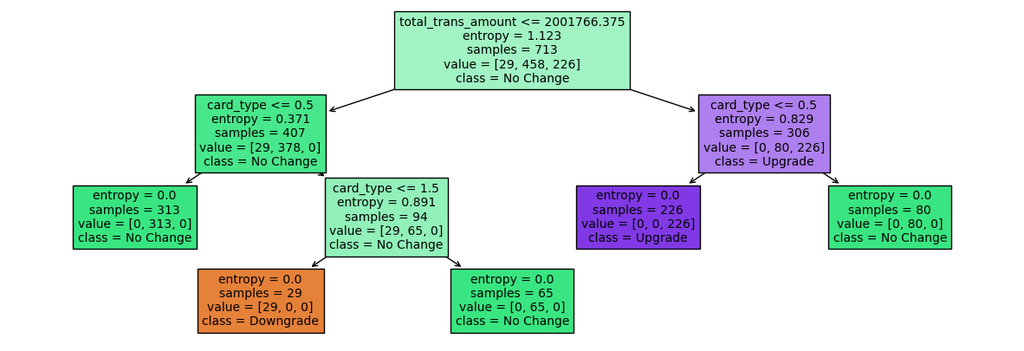

```python
plt.figure(figsize=(15,5))
tree.plot_tree(classifier,
               feature_names=["card_type", "total_trans_amount"],
               class_names=["Downgrade", "No Change", "Upgrade"],
               filled=True,
               fontsize=10)
plt.show()
```

```python
y_pred= classifier.predict(X_test)
```

```python
from sklearn.metrics import accuracy_score
print("Accuracy:",accuracy_score(y_test, y_pred))
```

```
Accuracy: 1.0
```

The model accurately predicts, based on clients card types and total spends (including negative and positive transactions), whether they are eligible for upgrades or not. It maintains integrity of clients such as their age as Junior cards do not get affected until they become classic. In order to maintain ethical considerations the model only looks at key parameters like transactions and not locational factors of the clients. Using a decision tree allows us to accurately look at the data and come to a conclusion of 'Upgrade', 'Downgrade' or 'No change' which other models would not be able to accurately predict.

## Age groups vs Amount of clients

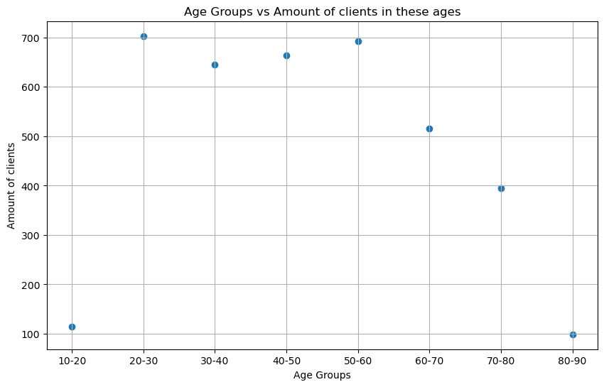

```python
import sqlite3
import pandas as pd
import matplotlib.pyplot as plt
from datetime import datetime

conn = sqlite3.connect('BankRecords.db')

sql_query = """SELECT a.account_id, c.birth_number
FROM account_df a
JOIN client_df c ON c.client_id = a.account_id"""

data = pd.read_sql_query(sql_query, conn)

data['age'] = data['birth_number'].apply(calculate_age)

def count_accounts_by_age_group(data):
    age_ranges = [(10, 20), (20, 30), (30, 40), (40, 50), (50, 60), (60, 70), (70, 80), (80, 90)]
    age_group_data = []
    for age_range in age_ranges:
        lower_age, upper_age = age_range
        age_group = f"{lower_age}-{upper_age}"
        count = ((data['age'] >= lower_age) & (data['age'] < upper_age)).sum()
        age_group_data.append({'age_group': age_group, 'account_count': count})
    return pd.DataFrame(age_group_data)

newData = count_accounts_by_age_group(data)

plt.figure(figsize=(10, 6))
plt.scatter(newData['age_group'], newData['account_count'])
plt.title('Age Groups vs Amount of clients in these ages')
plt.xlabel('Age Groups')
plt.ylabel('Amount of clients')
plt.grid(True)
```

```python
import numpy as np
import matplotlib.pyplot as plt
import seaborn as sns
from scipy import stats
import math as m
import pandas as pd
from sklearn import linear_model
from sklearn.preprocessing import LabelEncoder
Le = LabelEncoder()

newData['age_group'] = Le.fit_transform(newData['age_group'])

lrModel = linear_model.LinearRegression()
trainX = np.array(newData['age_group']).reshape(-1, 1)

lrModel.fit(X=trainX, y=newData['account_count'])
```

```
LinearRegression()
```

```python
print("Regression coefficient beta = %.3f" % (lrModel.coef_[0]))
```

```
Regression coefficient beta = -23.940
```

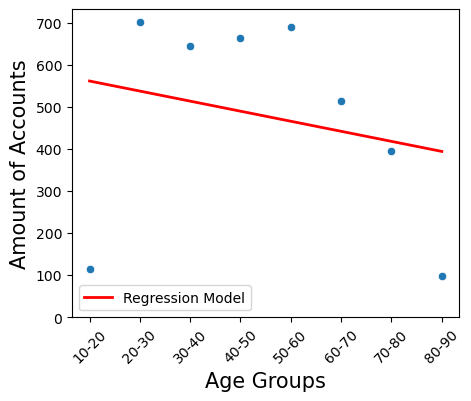

```python
import matplotlib.pyplot as plt
import seaborn as sns
import numpy as np
age_group_labels = ["10-20", "20-30", "30-40", "40-50", "50-60", "60-70", "70-80", "80-90"]

plt.figure(figsize=(5, 4), dpi=100)
ax = sns.scatterplot(x="age_group", y="account_count", data=newData, marker='o')
ax.set_xlabel('Age Groups', fontsize=15)
ax.set_ylabel('Amount of Accounts', fontsize=15)

ax.set_ylim(bottom=0)

x_values_for_prediction = np.arange(len(age_group_labels)).reshape(-1, 1)
predictAges = lrModel.predict(x_values_for_prediction)

sns.lineplot(x=np.arange(len(age_group_labels)), y=predictAges, linestyle='-', color="r", label="Regression Model", alpha=1, lw=2)

plt.xticks(ticks=np.arange(len(age_group_labels)), labels=age_group_labels, rotation=45)

plt.show()
```

By bringing in 'birth_number' and 'account_id' using SQL Statements it allows us to create new columns in the database using them such as 'age' using previously defined function 'calculate_age' with the assumption the current year is 1999. Then create a new function 'count_accounts_by_age_group' which sums the ages of clients and places them in an age group. Using linear regression model we can accurately see how 'Amount of Accounts' varies per age group in order to use to improve customer satisfaction. We can also see potential outliers using a scatter graph that can be key in evaluation.

## Predicts if a loan will be paid based on the duration of the loan and the average salary

```python
import sqlite3
import pandas as pd
from sklearn.preprocessing import LabelEncoder

conn = sqlite3.connect('BankRecords.db')

sql_query = """
SELECT l.loan_status, l.loan_duration
FROM loans_df l
"""

data = pd.read_sql_query(sql_query, conn)

loan_status_duration_table = data.groupby(['loan_status', 'loan_duration']).size().unstack(fill_value=0)

loan_status_duration_table
```

| loan_duration loan_status | 12 | 24 | 36 | 48 | 60 |
| --- | --- | --- | --- | --- | --- |
| A | 93 | 64 | 32 | 11 | 3 |
| B | 10 | 11 | 7 | 2 | 1 |
| C | 27 | 57 | 83 | 111 | 125 |
| D | 1 | 6 | 8 | 14 | 16 |

```python
import pandas as pd
from scipy.stats import chi2_contingency

chi2, p, dof, expected = chi2_contingency(loan_status_duration_table)

print("Chi-Square Statistic:", chi2)
print("P-value:", p)
```

```
Chi-Square Statistic: 246.51818703480063
P-value: 7.277819645944902e-46
```

```python
import sqlite3
import pandas as pd

conn = sqlite3.connect('BankRecords.db')

sql_query = """
SELECT l.loan_status, l.loan_duration, c.birth_number, ab.a11, a.account_id
FROM loans_df l
JOIN account_df a ON a.account_id = l.account_id
JOIN client_df c ON c.client_id = a.client_id
JOIN a_df ab ON ab.a1 = c.a1
"""

data = pd.read_sql_query(sql_query, conn)

data['age'] = data['birth_number'].apply(calculate_age)

data
```

|  | loan_status | loan_duration | birth_number | a11 | account_id | age |
| --- | --- | --- | --- | --- | --- | --- |
| 0 | A | 24 | 450204 | 12541 | 2 | 54 |
| 1 | B | 12 | 395423 | 9104 | 19 | 60 |
| 2 | A | 12 | 620209 | 9893 | 25 | 37 |
| 3 | D | 60 | 520826 | 8547 | 37 | 47 |
| 4 | C | 48 | 405130 | 8402 | 38 | 59 |
| ... | ... | ... | ... | ... | ... | ... |
| 677 | C | 24 | 795222 | 9920 | 11327 | 20 |
| 678 | C | 60 | 525909 | 9897 | 11328 | 47 |
| 679 | C | 60 | 456030 | 12541 | 11349 | 54 |
| 680 | A | 12 | 680413 | 8814 | 11359 | 31 |
| 681 | A | 24 | 626019 | 8110 | 11362 | 37 |

682 rows × 6 columns

```python
import pandas as pd
from scipy.stats import pearsonr


corr, p_value = pearsonr(data['a11'], data['loan_duration'])

print(f"Pearson Correlation Coefficient: {corr}")
print(f"P-value: {p_value}")
```

```
Pearson Correlation Coefficient: -0.08596684019700469
P-value: 0.024763360848835857
```

```python
from sklearn.linear_model import LogisticRegression

filtered_data = data[data['loan_status'].isin(['B', 'D'])]

Y_filtered = filtered_data['loan_status']
X_filtered = filtered_data[['loan_duration', 'a11']]

X_train_filtered, X_test_filtered, Y_train_filtered, Y_test_filtered = train_test_split(X_filtered, Y_filtered, test_size=0.3, random_state=0)

logistic_regression_model_filtered = LogisticRegression(max_iter=1000)
logistic_regression_model_filtered.fit(X_train_filtered, Y_train_filtered)
```

```
LogisticRegression(max_iter=1000)
```

```python
prediction=logistic_regression_model_filtered.predict(X_test_filtered)
```

```python
from sklearn.metrics import confusion_matrix
confusion_matrix(Y_test_filtered,prediction)
```

```
array([[ 9,  1],
       [ 3, 10]])
```

```python
from sklearn.metrics import accuracy_score
model_accuracy=accuracy_score(Y_test_filtered,prediction)
model_accuracy
```

```
0.8260869565217391
```

## Model to predict card types and their most common usage

```python
import sqlite3
import pandas as pd
import matplotlib.pyplot as plt
import seaborn as sns;sns.set
import numpy as np
from sklearn.cluster import KMeans

conn = sqlite3.connect('BankRecords.db')

sql_query = """SELECT ca.card_type, t.trans_detail
FROM account_df a
JOIN disposition_df d ON d.account_id = a.account_id
JOIN card_df ca ON ca.disp_id = d.disp_id
JOIN transaction_df t ON t.account_id = a.account_id"""

data = pd.read_sql_query(sql_query, conn)

from sklearn.preprocessing import LabelEncoder
Le = LabelEncoder()

data['card_type'] = Le.fit_transform(data['card_type'])
data['trans_detail'] = Le.fit_transform(data['trans_detail'])

data = data.dropna(subset=['trans_detail'])

y_card = data['trans_detail']
X_card = data.drop(['trans_detail'],axis=1)
```

```python
# Fitting the model
from sklearn import tree
clf = tree.DecisionTreeClassifier(criterion = 'entropy')
clf = clf.fit(X_card, y_card)
```

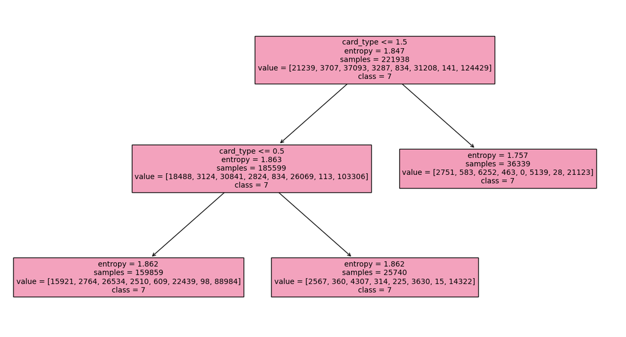

```python
plt.figure(figsize=(15,8))
tree.plot_tree(clf,
               feature_names=["card_type", "trans_detail"],
               class_names=["0", "1", "2", "3", "4", "5", "6", "7"],
               filled=True,
               fontsize=10)
plt.show()
```

```python
from sklearn.model_selection import train_test_split
X_train_card, X_test_card, y_train_card, y_test_card = train_test_split(X_card, y_card, test_size=0.30)

from sklearn.tree import DecisionTreeClassifier
classifier =DecisionTreeClassifier(criterion="entropy", random_state=100)
classifier.fit(X_train_card, y_train_card)
```

```
DecisionTreeClassifier(criterion='entropy', random_state=100)
```

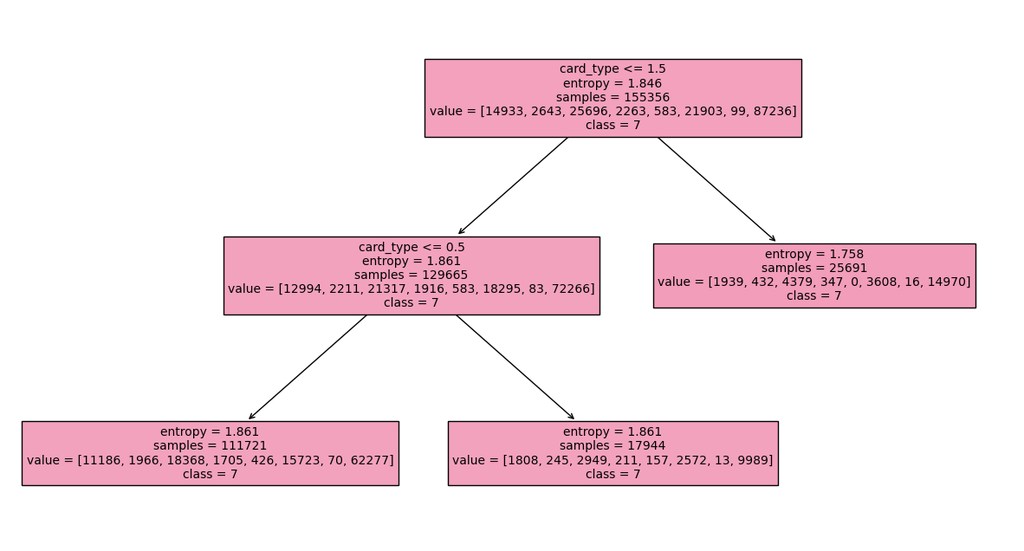

```python
plt.figure(figsize=(15,8))
tree.plot_tree(classifier,
               feature_names=["card_type", "trans_detail"],
               class_names=["0", "1", "2", "3", "4", "5", "6", "7"],
               filled=True,
               fontsize=10)
plt.show()
```

```python
y_pred_card= classifier.predict(X_test_card)
```

```python
from sklearn.metrics import accuracy_score
print("Accuracy:",accuracy_score(y_test_card, y_pred_card))
```

```
Accuracy: 0.5586044276230813
```

## Task 4: Experimental Results and Analysis (25 Marks)

Given the **five** modelling solutions implemented above, analyse, discuss and present your findings to the key stakeholders of the bank.

Your answer should clearly cover the following:

- Present your findings in a clear and concise manner;
- Discuss your results in the context of the selected solution;
- Discuss how these results can help the bank in performing customer risk assessment and establishing customer retention strategies;
- Present the limitations (if any) of your solutions in a clear and concise manner.

**World Limit**: 500 words. This limit applies only to the explanations. There is no limit on any associated code or figures.

**Write your answer here (text cell(s) to be used, as appropriate)**

### Figure 1.1

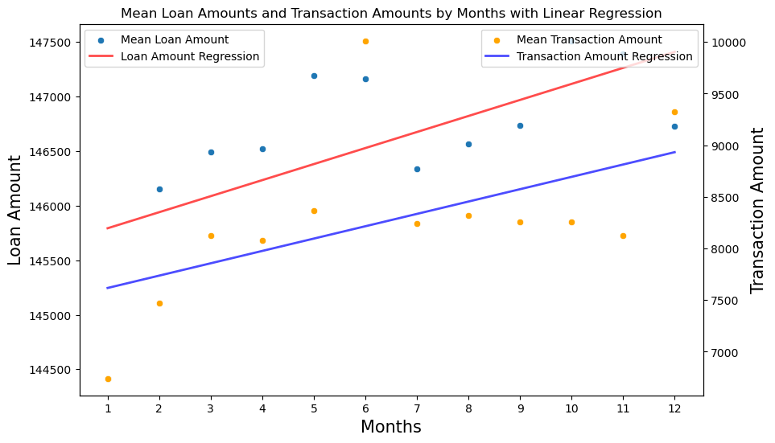

The starting mean loan amount is £145,646.544. For transactions, it is £7,497.622. By having larger loan amounts correlating with transaction behaviours per month, banks can highlight these data points for analysing future clients for retention, these trends aid in risk assessment.

However, the model has limitations as regression does not imply causation, outliers or market events may have an impact on the data.

## Figure 1.2

[figure not shown]

The decision tree (Figure 1.2) analyses and predicts if a client should have their card type upgraded, downgraded or stay the same based off a £2,000,000 threshold. A table is created by a function that calculates the results intially.

This offers the bank a tool for customer segmentation, allowing them to see high-transacting customers for exclusive offers or identifying lower transacting ones for downgrades, this aids in customer satisfaction and targeted marketing.

However, the 100% accuracy suggests potential overfitting, which could mean the model may not perform as well to unseen data.

## Figure 1.3

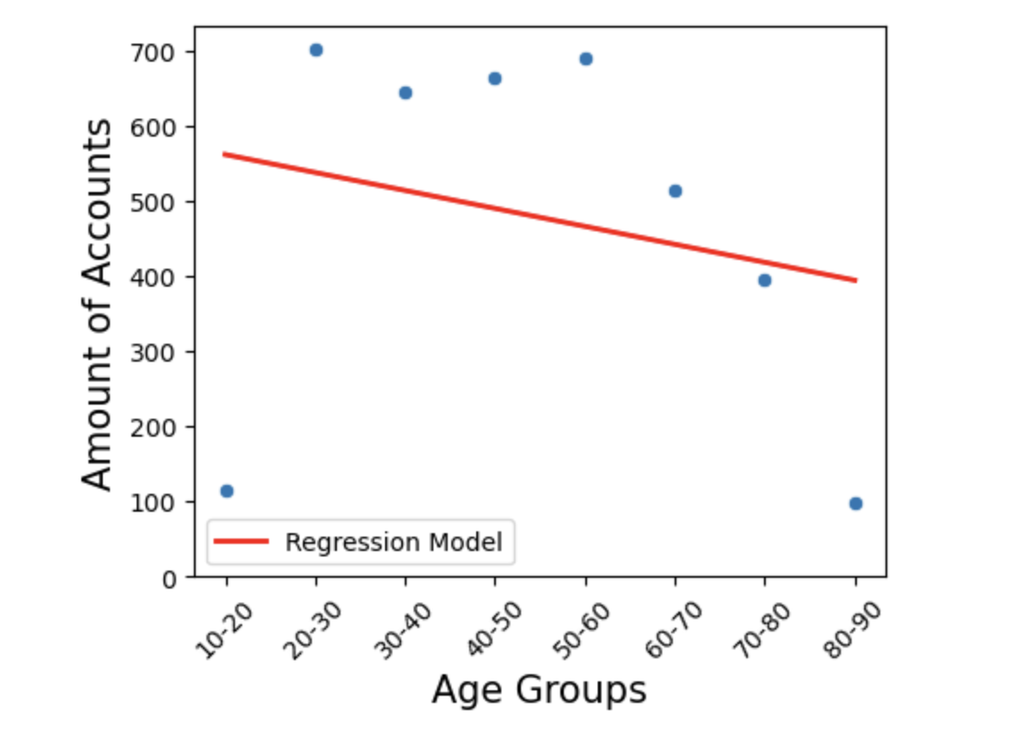

The linear regression analysis (Figure 1.3) shows a downward trend in the number of accounts as customers age increases. This could suggest that older age groups move to different banks.

For banks, this trend could inform risk assessment strategies to maintain current customers such as focusing on older demographics to introduce a 'Senior' card type with more tailored benefits or loyalty benefits.

However, the model's limitations includes outliers that effect its accuracy at predicting the amount of accounts as people age by missing potential key information nor does it take into account global context.

## Figure 1.4

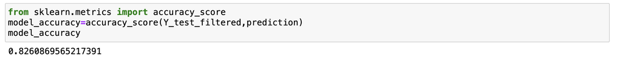

Initially combining loan status and duration it highlighted shorter loans succeed and longer loans create more risk. A logistic regression, chosen for binary outcomes, predicted loans that wont be repaid with 82.6% accuracy (Figure 1.4) , using salary and loan duration for further factors to analyse.

This allows the banks to take into account peoples average salaries and determine what loan duration to offer them.

However, the model is objective as banks want loans to be repaid prompting ethical issues. It's crucial to use the model as a guide, considering broader financial contexts of each client when making lending decisions.

## Figure 1.5

[figure not shown]

It provides a basis for the bank to look at each card types most common transaction type and adjust their card benefits and potential drawbacks for transaction types to improve customers satisfaction based on common spending behaviour of clients who use their given card

However, while useful for initial insights into card usage, the accuracy level requires further refinement for a more reliable strategy model for determining card usage.

## Task 5: Conclusion (10 Marks)

Given the insights derived from Tasks 1-4, provide a conclusion that clearly covers the following:

- A summary of the main points;
- A discussion of the significance of your results;
- Any recommendation(s) resulting from your analysis;
- Any overall ethical considerations arising from the data analysis of this business domain.

**World Limit**: 300 words.

**Write your answer here (text cell(s) to be used, as appropriate)**

Overall, the five models created allow the bank to make clear assessment of their customers, how people use and interact with their cards whilst also being able to make predictions on what they're spending on. All of this allows the bank to make accurate and informed decision-making within the organisation in order to succesfully improve customer-satisfaction and retaining customers long term.

The results provided showcase a vast range of areas that the bank can capitalise on to improve and reward clients. For example, when to approach customers and offer loans in order to benefit both parties. They can also take this further by examining their transactions and client salaries in order to offer a safer loan duration when doing so creating less risk for both the organisation along with the client. By giving clients that safety from analysing previous loans it vastly improves their trust and relationship with the bank solidifying their retention. Now that the bank has a clearer picture of their demographic through looking at how different age groups interact with the bank and how their relationships change as clients age they can focus on retaining an aging generation by creating a pension scheme or developing new 'Senior' cards to correspond with their 'Junior' range and potentially upgrading current cards by taking into account their total transactions. This can potentially improve customer retention and we wont see the drop off in accounts at later age groups, from people potentially move to other banking organisations, through their loyalty and the benefits that come with.

Although these models offer great insight into the banks organisation, it is still vital to look further into the ethics and the greater global context combine with economic factors that come with in order to make final the justifications.

## Overall Academic Quality (10 Marks)

10 marks are allocated for the clarity and cohesiveness of your answers (both text and code) across all tasks with appropriate, relevant and effective analysis and presentation of the results.

## Deliverables

You should submit the following to the submission point on the teaching portal:

1. the SQLite database produced in Task 2;
2. the completed Jupyter notebook (both .ipynb and HTML files) that also includes the SQL statements (Task 2), the research design and its implementation (Task 3), and the analysis and presentation of your results (Task 4);
3. any figures or diagrams that are included in your answers in the Jupyter notebook.

For each task where text is required, we have provided guidelines above on the suggested word counts. Exceeding the word count will result in any work beyond the word count being disregarded when assessing.